# Class 2

Colin Kuehl

September 01, 2022

Load the Simpson’s dataset from the book chapter

```r
load("donutd.RData")
```

Looking over the data

```r
head(donutd)
```

```
##           name donuts weight child male donutsXnew
## 1        Homer  14.00    275     0    0      14.00
## 2        Marge   0.00    141     0    1       0.00
## 3         Lisa   0.00     70    -1    1       0.00
## 4         Bart   5.00     75    -1    0       5.00
## 5 ComicBookGuy  20.00    310     0    0      20.00
## 6     Mr Burns   0.75     80     0    0       0.75
```

```r
tail(donutd)
```

```
##                 name donuts weight child male donutsXnew
## 8       Chief Wiggum   16.0    263     0    0       16.0
## 9  Principal Skinner    3.0    205     0    0        3.0
## 10      Rev. Lovejoy    2.0    185     0    0        2.0
## 11      Ned Flanders    0.8    170     0    0        0.8
## 12             Patty    5.0    155     0    1        5.0
## 13             Selma    4.0    145     0    1        4.0
```

```r
summary(donutd)
```

```
##      name               donuts           weight          child
##  Length:13          Min.   : 0.000   Min.   : 70.0   Min.   :-1.0000
##  Class :character   1st Qu.: 0.750   1st Qu.:141.0   1st Qu.: 0.0000
##  Mode  :character   Median : 3.000   Median :160.0   Median : 0.0000
##                     Mean   : 5.446   Mean   :171.8   Mean   :-0.1538
##                     3rd Qu.: 5.000   3rd Qu.:205.0   3rd Qu.: 0.0000
##                     Max.   :20.000   Max.   :310.0   Max.   : 0.0000
##       male          donutsXnew
##  Min.   :0.0000   Min.   : 0.000
##  1st Qu.:0.0000   1st Qu.: 0.750
##  Median :0.0000   Median : 3.000
##  Mean   :0.3077   Mean   : 5.446
##  3rd Qu.:1.0000   3rd Qu.: 5.000
##  Max.   :1.0000   Max.   :20.000
```

```r
dim(donutd) #Count of how many observations and variables
```

```
## [1] 13  6
```

male and name are not continuous(numeric in R speak) variables.

frequency tables:

```r
table(donutd$male) #gives count of different categories
```

```
##
## 0 1
## 9 4
```

```r
table(donutd$name)
```

```
##
##              Bart      Chief Wiggum      ComicBookGuy             Homer
##                 1                 1                 1                 1
##              Lisa             Marge          Mr Burns      Ned Flanders
##                 1                 1                 1                 1
##             Patty Principal Skinner      Rev. Lovejoy             Selma
##                 1                 1                 1                 1
##          Smithers
##                 1
```

```r
prop.table(table(donutd$male)) #gives percentages
```

```
##
##         0         1
## 0.6923077 0.3076923
```

What percentage of the individuals in the dataset are children?

Plot the relationship between donuts and weight

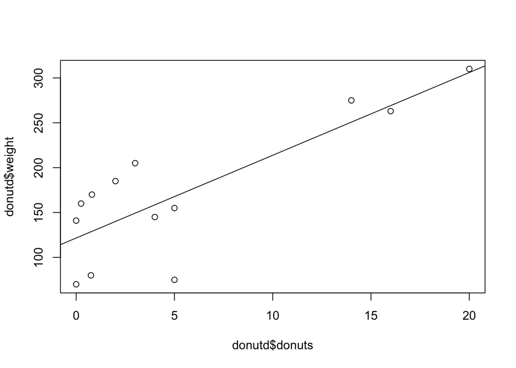

```r
plot(donutd$donuts, donutd$weight) #scatterplot (X then Y)
abline(lm(donutd$weight~donutd$donuts)) #add trend line (Y then X)
```

Make plot look a bit more respectable

[figure not shown]

```r
plot(donutd$donuts, donutd$weight, main="Relationship between Donut Consumption and Weight", xlab="Donuts", ylab="Weight")
abline(lm(donutd$weight~donutd$donuts)) #and boom, you've already ran your 2nd regression
text(donutd$donuts, donutd$weight-12, donutd$name)#add labels(the -12 is to offset the label)
```

Does there appear to be a relationship in the sample?

What about with just males? There are multiple ways to do this:

First, off we don’t think we’ll reuse the dataset we can pull out what we need in the code

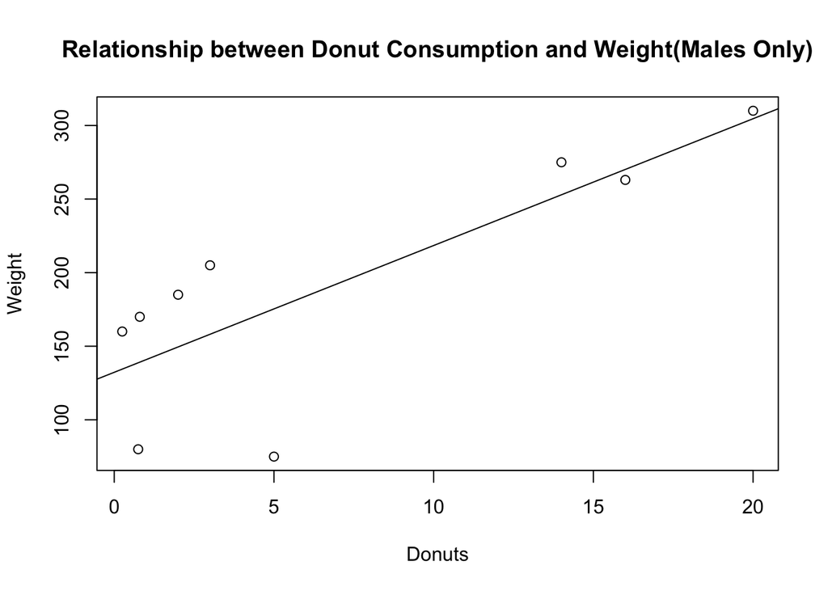

```r
plot(donutd$donuts[donutd$male==0], donutd$weight[donutd$male==0], main="Relationship between Donut Consumption and Weight(Males Only)", xlab="Donuts", ylab="Weight") #The [donutd$male==1] is telling R to only include dots where male=1, ie only males.
abline(lm(donutd$weight[donutd$male==0]~donutd$donuts[donutd$male==0])) #
```

Or we can create a new dataset(I usually choose this option)

[figure not shown]

```r
males <- donutd[which(donutd$male==0),]

plot(males$donuts, males$weight, main="Relationship between Donut Consumption and Weight", xlab="Donuts", ylab="Weight")
abline(lm(males$weight~males$donuts)) #and boom, you've already ran your 2nd regression
text(males$donuts, males$weight-12, males$name)
```

Heads Up: We will practice this a third way using the dplyr package in the coming weeks

Other ways to subset:

Exclude kids

```r
adults <- donutd[which(donutd$child!=-1),] # the != does not equal
```

Exclude overweight

```r
normweight <- donutd[which(donutd$weight< 250),] # the
```

Try creating a scatterplot with just the 1) females 2) characters who at least eat donuts.

[figure not shown]

```r
donuteaters <- donutd[which(donutd$donuts> 0),]

plot(donuteaters$donuts, donuteaters$weight, main="Relationship between Donut Consumption and Weight", sub="Donut Eaters", xlab="Donuts", ylab="Weight")
abline(lm(donuteaters$weight~donuteaters$donuts)) #and boom, you've already ran your 2nd regression
text(donuteaters$donuts, donuteaters$weight-12, donuteaters$name)
```

#Looking at a different dataset: Time to look at something a bit more fun. World cup players. The data are from this article: https://projects.fivethirtyeight.com/world-cup-comparisons/landon-donovan-2010/

We want to load a csv file into R. Here’s how you do it. Make that sure when you do this, your data is in the same working directory that you set your assignment in(This allows us to avoid typing out the whole file path). It is easy to save excel files as csv

```r
wc <- read.csv("wc.csv", header=T)
```

Different file formats have different load commands. If your data is already saved as an .RData file (hint hint, check the problem set data), then run this code:load(“name_of_data_set.RData”) We’re not going to run it here, because we only have a CSV dataset.

R can load excel, spss, stata, text, etc. if you use the right command.

Remember all these indicators are z-standardized.

```r
head(wc)
```

```
##   X          player season      team goals_z  xg_z crosses_z boxtouches_z
## 1 1  Cristian Pavón   2018 Argentina   -0.42 -0.55      0.08        -0.24
## 2 2  Eduardo Salvio   2018 Argentina   -0.42 -0.50     -0.51         0.64
## 3 3      Enzo Pérez   2018 Argentina   -0.42  0.11     -0.51        -0.69
## 4 4  Federico Fazio   2018 Argentina   -0.42 -0.59     -0.51        -0.69
## 5 5   Franco Armani   2018 Argentina   -0.42 -0.59     -0.51        -0.80
## 6 6 Gabriel Mercado   2018 Argentina    1.30 -0.30      0.08        -0.35
##   passes_z progpasses_z takeons_z progruns_z tackles_z interceptions_z
## 1    -0.61        -0.72     -0.05       0.15      0.30           -0.79
## 2     0.02        -0.46     -0.05       0.48      0.61            0.67
## 3     0.27        -0.65     -0.36      -0.34      0.35           -0.22
## 4    -0.97        -0.91     -0.67      -0.84     -0.82           -0.79
## 5    -0.67         0.64     -0.67      -0.67     -0.82           -0.79
## 6     1.00        -0.20     -0.36       0.15      1.43            0.79
##   clearances_z blocks_z aerials_z fouls_z fouled_z nsxg_z
## 1        -0.80    -0.45     -0.23   -0.38    -0.91  -0.58
## 2         0.32    -0.45      0.21   -1.11     0.68  -0.03
## 3        -0.80    -0.45     -0.89    0.72     0.04  -0.66
## 4        -0.64    -0.45      0.21   -1.11    -0.59  -0.77
## 5        -0.64    -0.45     -0.89   -1.11    -0.91  -0.77
## 6         0.64     0.73     -0.01    1.81     0.68  -0.47
```

```r
tail(wc)
```

```
##         X           player season         team goals_z  xg_z crosses_z
## 5894 5894   Siegfried Held   1966 West Germany    0.45  1.18      2.62
## 5895 5895       Uwe Seeler   1966 West Germany    1.28  3.01     -0.08
## 5896 5896    Werner Krämer   1966 West Germany   -0.39 -0.63      0.46
## 5897 5897     Willi Schulz   1966 West Germany   -0.39 -0.63     -0.35
## 5898 5898 Wolfgang Overath   1966 West Germany   -0.39 -0.12      0.73
## 5899 5899   Wolfgang Weber   1966 West Germany    0.45 -0.16     -0.62
##      boxtouches_z passes_z progpasses_z takeons_z progruns_z tackles_z
## 5894         1.86     0.45         0.05      1.69       2.94     -0.70
## 5895         4.34     0.04        -0.65     -0.42      -0.03     -0.68
## 5896        -0.51    -1.53        -1.11     -0.60      -0.73     -1.10
## 5897        -0.67     0.49         0.41     -0.77      -0.66      1.48
## 5898         0.05     1.82         0.87      0.11       0.26      1.64
## 5899        -0.41    -0.55        -0.41     -0.60      -0.52      0.17
##      interceptions_z clearances_z blocks_z aerials_z fouls_z fouled_z nsxg_z
## 5894           -0.54        -0.69    -0.18     -0.10   -0.09     1.43   2.98
## 5895           -0.01        -0.63    -0.26      2.90   -0.09     2.14   0.38
## 5896           -0.85        -0.69    -0.62     -0.60   -1.21    -0.34  -0.17
## 5897            0.70         2.45     3.12      0.15    0.10    -0.51  -0.60
## 5898            1.49        -0.46    -0.62     -0.35    1.60     0.55   0.41
## 5899            1.77         2.05     0.46      1.65   -0.09     1.25  -0.86
```

Look at variable names

```r
names(wc)
```

```
##  [1] "X"               "player"          "season"          "team"
##  [5] "goals_z"         "xg_z"            "crosses_z"       "boxtouches_z"
##  [9] "passes_z"        "progpasses_z"    "takeons_z"       "progruns_z"
## [13] "tackles_z"       "interceptions_z" "clearances_z"    "blocks_z"
## [17] "aerials_z"       "fouls_z"         "fouled_z"        "nsxg_z"
```

Number of rows in your data?

```r
nrow(wc)
```

```
## [1] 5899
```

Number of columns in your data?

```r
ncol(wc)
```

```
## [1] 20
```

Dimensions of your data? # Observations then # of Variables

```r
dim(wc)
```

```
## [1] 5899   20
```

Range of goals in this data

```r
range(wc$goals_z) #Decimal because z-standardized
```

```
## [1] -0.50 10.12
```

Summary of the data will give you mean, minimum, maximum values, etc.

```r
summary(wc$goals_z)
```

```
##      Min.   1st Qu.    Median      Mean   3rd Qu.      Max.
## -0.500000 -0.420000 -0.410000  0.000044 -0.390000 10.120000
```

```r
summary(wc) # Runs for all variables in the dataset
```

```
##        X           player              season         team
##  Min.   :   1   Length:5899        Min.   :1966   Length:5899
##  1st Qu.:1476   Class :character   1st Qu.:1986   Class :character
##  Median :2950   Mode  :character   Median :1998   Mode  :character
##  Mean   :2950                      Mean   :1996
##  3rd Qu.:4424                      3rd Qu.:2010
##  Max.   :5899                      Max.   :2018
##     goals_z               xg_z             crosses_z
##  Min.   :-0.500000   Min.   :-0.720000   Min.   :-0.750000
##  1st Qu.:-0.420000   1st Qu.:-0.590000   1st Qu.:-0.570000
##  Median :-0.410000   Median :-0.390000   Median :-0.510000
##  Mean   : 0.000044   Mean   : 0.000161   Mean   : 0.000227
##  3rd Qu.:-0.390000   3rd Qu.: 0.200000   3rd Qu.: 0.200000
##  Max.   :10.120000   Max.   : 8.600000   Max.   : 8.080000
##   boxtouches_z          passes_z          progpasses_z
##  Min.   :-0.810000   Min.   :-1.650000   Min.   :-1.320000
##  1st Qu.:-0.700000   1st Qu.:-0.800000   1st Qu.:-0.800000
##  Median :-0.370000   Median :-0.170000   Median :-0.260000
##  Mean   :-0.000532   Mean   : 0.000003   Mean   : 0.000056
##  3rd Qu.: 0.270000   3rd Qu.: 0.630000   3rd Qu.: 0.550000
##  Max.   : 7.510000   Max.   : 5.120000   Max.   : 5.530000
##    takeons_z           progruns_z          tackles_z       interceptions_z
##  Min.   :-0.910000   Min.   :-1.180000   Min.   :-1.1000   Min.   :-1.030000
##  1st Qu.:-0.680000   1st Qu.:-0.730000   1st Qu.:-0.7700   1st Qu.:-0.790000
##  Median :-0.320000   Median :-0.290000   Median :-0.3000   Median :-0.290000
##  Mean   :-0.000603   Mean   :-0.000066   Mean   : 0.0001   Mean   : 0.000144
##  3rd Qu.: 0.335000   3rd Qu.: 0.460000   3rd Qu.: 0.4700   3rd Qu.: 0.460000
##  Max.   : 9.180000   Max.   : 7.340000   Max.   : 6.6600   Max.   : 5.740000
##   clearances_z          blocks_z           aerials_z
##  Min.   :-0.800000   Min.   :-0.620000   Min.   :-0.890000
##  1st Qu.:-0.680000   1st Qu.:-0.560000   1st Qu.:-0.690000
##  Median :-0.420000   Median :-0.480000   Median :-0.310000
##  Mean   : 0.000312   Mean   :-0.000432   Mean   : 0.000393
##  3rd Qu.: 0.260000   3rd Qu.: 0.230000   3rd Qu.: 0.280000
##  Max.   : 5.780000   Max.   :10.910000   Max.   :10.220000
##     fouls_z             fouled_z             nsxg_z
##  Min.   :-1.280000   Min.   :-1.100000   Min.   :-1.01000
##  1st Qu.:-0.790000   1st Qu.:-0.710000   1st Qu.:-0.73000
##  Median :-0.180000   Median :-0.280000   Median :-0.34000
##  Mean   :-0.000212   Mean   :-0.000046   Mean   : 0.00009
##  3rd Qu.: 0.570000   3rd Qu.: 0.450000   3rd Qu.: 0.38000
##  Max.   : 6.860000   Max.   : 6.770000   Max.   : 7.28000
```

Mean of goals?

```r
mean(wc$goals_z)
```

```
## [1] 4.407527e-05
```

Minimum of goals?

```r
min(wc$goals_z)
```

```
## [1] -0.5
```

Maximum number of goals?

```r
max(wc$goals_z)
```

```
## [1] 10.12
```

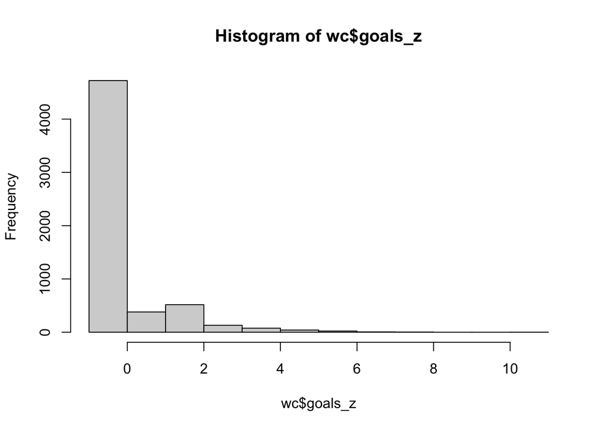

```r
hist(wc$goals_z)
```

#creating new variables

What if we wanted to an aggregrate indicator for how aggressive each player is on offense.

R understands standard addition, subtraction, multiplication, division, etc.

```r
wc$off <- wc$progpasses_z + wc$progruns_z
mean(wc$off) #doesn't mean much because z-scored
```

```
## [1] -1.017122e-05
```

```r
min(wc$off)
```

```
## [1] -2.39
```

```r
max(wc$ofF)
```

```
## [1] -Inf
```

```r
#lets add crosses and take ons and then average the z-score. Notice R is following the order of operations
wc$offplus <- (wc$off + wc$crosses_z + wc$takeons_z)/4
summary(wc$offplus)
```

```
##      Min.   1st Qu.    Median      Mean   3rd Qu.      Max.
## -1.005000 -0.537500 -0.187500 -0.000097  0.345000  5.050000
```

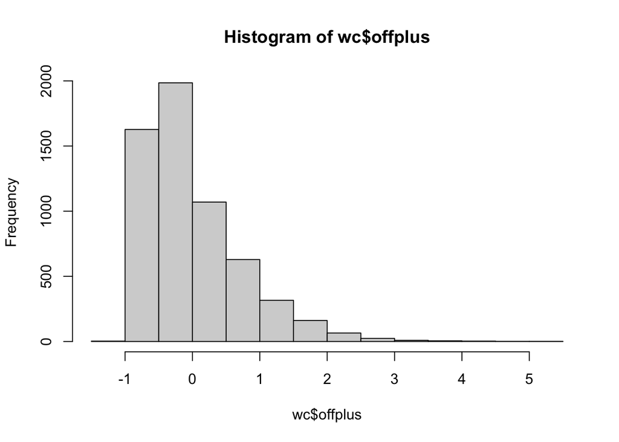

```r
hist(wc$offplus)
```

Let’s make a simple scatterplot with expected goals in the horizontal axis, and goals on the vertical axis, with labels. Let’s type out a regression (Looking at the relationship between variables), and then let’s add a regression line linear regression model, and you’re looking at the effect of the IV on the DV

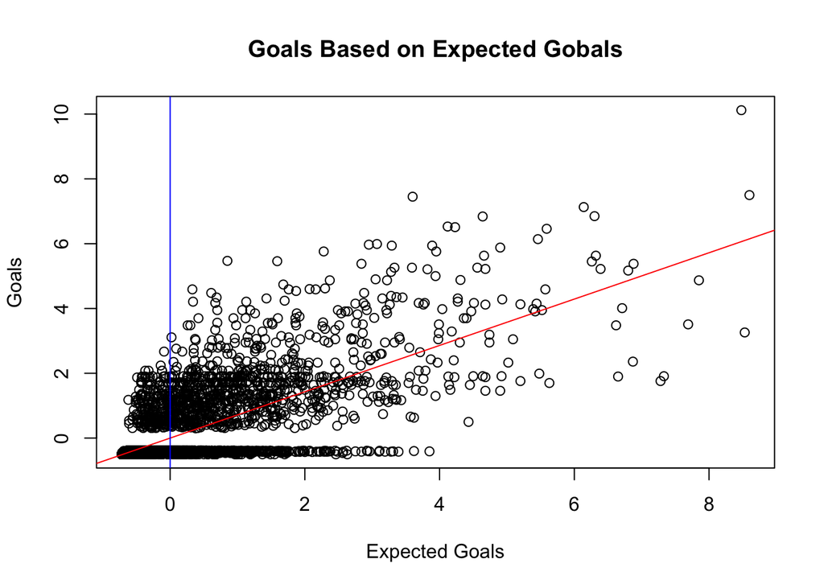

```r
plot(wc$xg_z, wc$goals_z, ylab = "Goals", xlab = "Expected Goals", main = "Goals Based on Expected Gobals")
abline(lm(wc$goals_z ~ wc$xg_z), col="red") # What type of relationship is this?
abline(v=mean(wc$xg_z), col="blue")
```

That is a bit overwhelming lets just look at the most recent world cup

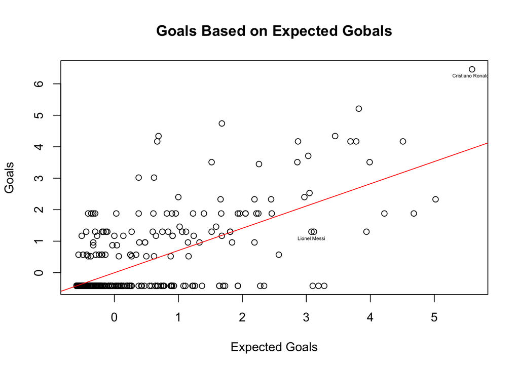

```r
france18 <- wc[which(wc$season==2018),]
plot(france18$xg_z, france18$goals_z, ylab = "Goals", xlab = "Expected Goals", main = "Goals Based on Expected Gobals")
abline(lm(france18$goals_z ~ france18$xg_z), col="red")


france18$stars <- ifelse(france18$player=="Lionel Messi"|france18$player=="Cristiano Ronaldo", france18$player, "")
text(france18$xg_z, france18$goals_z-.2, france18$stars, cex=.4)
```

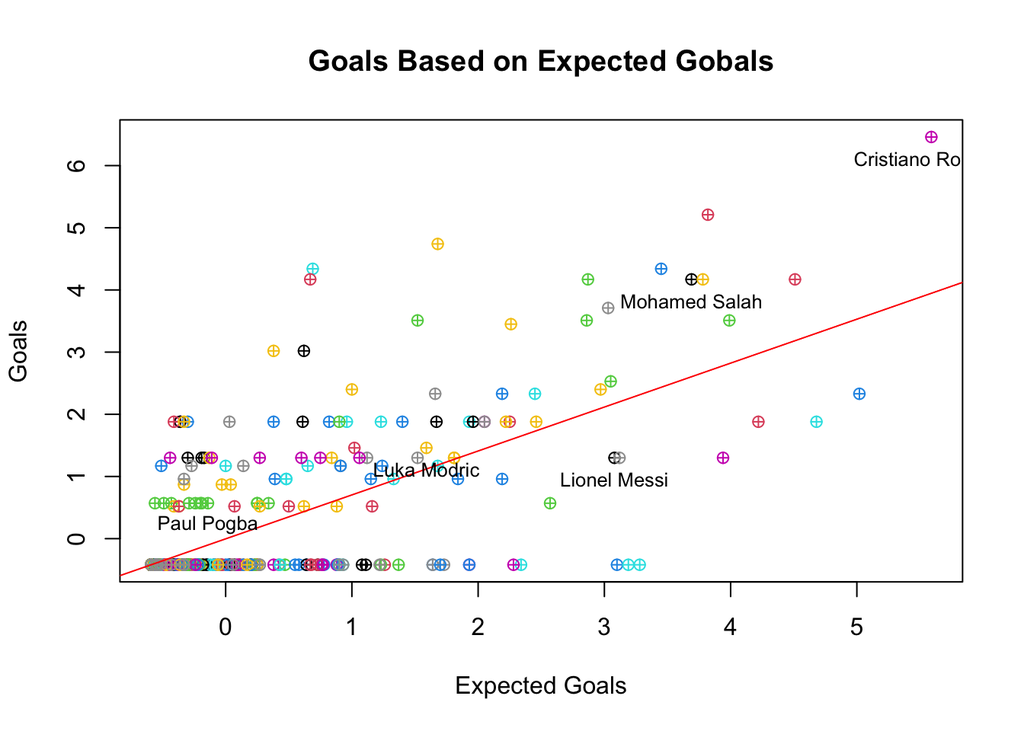

```r
plot(france18$xg_z, france18$goals_z, ylab = "Goals", xlab = "Expected Goals", main = "Goals Based on Expected Gobals", col=as.factor(france18$team), pch=10)
abline(lm(france18$goals_z ~ france18$xg_z), col="red")

france18$stars2 <- ifelse(france18$player=="Lionel Messi"|france18$player=="Cristiano Ronaldo"|france18$player=="Mohamed Salah"|france18$player=="Luka Modric"|france18$player=="Paul Pogba", france18$player, "")
text(france18$xg_z, france18$goals_z-.35, france18$stars2, cex=.8) #cex is text size
```

I’ve clearly had too much fun. Your turn to make something cool

Since we’ve created some new variables we may want to save our data:

```r
write.csv(wc, "wcv2.csv") #writes a csv to your working directory
save(wc, file="wcv2.RData") #saves Rdata format to your working directory
```

Note: you can open this new file in excel

Challenge: Create a plot for a single team(country+year) and create an interesting plot with player names

Bonus: Using WC prove why Messi is the best player of all time.